# Risk Factor Analysis

## Outcome Variable

**Outcome Variable:** sstunted

## Predictor Variables

**Intervention Variable:** birthlen

**Adjustment Set:**

- arm
- sex
- W_mage
- meducyrs
- feducyrs
- hhwealth_quart
- vagbrth
- W_nrooms
- brthmon
- W_parity
- impfloor
- impsan
- safeh20
- delta_W_mage
- delta_meducyrs
- delta_feducyrs
- delta_hhwealth_quart
- delta_vagbrth
- delta_W_nrooms
- delta_brthmon
- delta_W_parity
- delta_impfloor
- delta_impsan
- delta_safeh20

## Stratifying Variables

The analysis was stratified on these variable(s):

- agecat
- studyid
- country

## Data Summary

| agecat | studyid | country | birthlen | sstunted | n_cell | n |
| --- | --- | --- | --- | --- | --- | --- |
| Birth | ki0047075b-MAL-ED | BANGLADESH | >=50 cm | 0 | 29 | 257 |
| Birth | ki0047075b-MAL-ED | BANGLADESH | >=50 cm | 1 | 0 | 257 |
| Birth | ki0047075b-MAL-ED | BANGLADESH | <48 cm | 0 | 135 | 257 |
| Birth | ki0047075b-MAL-ED | BANGLADESH | <48 cm | 1 | 9 | 257 |
| Birth | ki0047075b-MAL-ED | BANGLADESH | [48-50) cm | 0 | 84 | 257 |
| Birth | ki0047075b-MAL-ED | BANGLADESH | [48-50) cm | 1 | 0 | 257 |
| Birth | ki0047075b-MAL-ED | BRAZIL | >=50 cm | 0 | 34 | 191 |
| Birth | ki0047075b-MAL-ED | BRAZIL | >=50 cm | 1 | 0 | 191 |
| Birth | ki0047075b-MAL-ED | BRAZIL | <48 cm | 0 | 72 | 191 |
| Birth | ki0047075b-MAL-ED | BRAZIL | <48 cm | 1 | 8 | 191 |
| Birth | ki0047075b-MAL-ED | BRAZIL | [48-50) cm | 0 | 77 | 191 |
| Birth | ki0047075b-MAL-ED | BRAZIL | [48-50) cm | 1 | 0 | 191 |
| Birth | ki0047075b-MAL-ED | INDIA | >=50 cm | 0 | 25 | 206 |
| Birth | ki0047075b-MAL-ED | INDIA | >=50 cm | 1 | 0 | 206 |
| Birth | ki0047075b-MAL-ED | INDIA | <48 cm | 0 | 100 | 206 |
| Birth | ki0047075b-MAL-ED | INDIA | <48 cm | 1 | 7 | 206 |
| Birth | ki0047075b-MAL-ED | INDIA | [48-50) cm | 0 | 74 | 206 |
| Birth | ki0047075b-MAL-ED | INDIA | [48-50) cm | 1 | 0 | 206 |
| Birth | ki0047075b-MAL-ED | NEPAL | >=50 cm | 0 | 38 | 173 |
| Birth | ki0047075b-MAL-ED | NEPAL | >=50 cm | 1 | 0 | 173 |
| Birth | ki0047075b-MAL-ED | NEPAL | <48 cm | 0 | 63 | 173 |
| Birth | ki0047075b-MAL-ED | NEPAL | <48 cm | 1 | 6 | 173 |
| Birth | ki0047075b-MAL-ED | NEPAL | [48-50) cm | 0 | 66 | 173 |
| Birth | ki0047075b-MAL-ED | NEPAL | [48-50) cm | 1 | 0 | 173 |
| Birth | ki0047075b-MAL-ED | PERU | >=50 cm | 0 | 34 | 287 |
| Birth | ki0047075b-MAL-ED | PERU | >=50 cm | 1 | 0 | 287 |
| Birth | ki0047075b-MAL-ED | PERU | <48 cm | 0 | 134 | 287 |
| Birth | ki0047075b-MAL-ED | PERU | <48 cm | 1 | 8 | 287 |
| Birth | ki0047075b-MAL-ED | PERU | [48-50) cm | 0 | 111 | 287 |
| Birth | ki0047075b-MAL-ED | PERU | [48-50) cm | 1 | 0 | 287 |

[output cut: 432 more lines]

The following strata were considered:

- agecat: 24 months, studyid: ki0047075b-MAL-ED, country: BANGLADESH
- agecat: 24 months, studyid: ki0047075b-MAL-ED, country: BRAZIL
- agecat: 24 months, studyid: ki0047075b-MAL-ED, country: INDIA
- agecat: 24 months, studyid: ki0047075b-MAL-ED, country: NEPAL
- agecat: 24 months, studyid: ki0047075b-MAL-ED, country: PERU
- agecat: 24 months, studyid: ki0047075b-MAL-ED, country: SOUTH AFRICA
- agecat: 24 months, studyid: ki0047075b-MAL-ED, country: TANZANIA, UNITED REPUBLIC OF
- agecat: 24 months, studyid: ki1000108-CMC-V-BCS-2002, country: INDIA
- agecat: 24 months, studyid: ki1000108-IRC, country: INDIA
- agecat: 24 months, studyid: ki1017093-NIH-Birth, country: BANGLADESH
- agecat: 24 months, studyid: ki1017093b-PROVIDE, country: BANGLADESH
- agecat: 24 months, studyid: ki1017093c-NIH-Crypto, country: BANGLADESH
- agecat: 24 months, studyid: ki1101329-Keneba, country: GAMBIA
- agecat: 24 months, studyid: ki1114097-CMIN, country: BANGLADESH
- agecat: 24 months, studyid: ki1114097-CMIN, country: PERU
- agecat: 24 months, studyid: ki1114097-CONTENT, country: PERU
- agecat: 24 months, studyid: ki1119695-PROBIT, country: BELARUS
- agecat: 24 months, studyid: ki1126311-ZVITAMBO, country: ZIMBABWE
- agecat: 24 months, studyid: ki1135781-COHORTS, country: GUATEMALA
- agecat: 24 months, studyid: ki1135781-COHORTS, country: INDIA
- agecat: 24 months, studyid: ki1135781-COHORTS, country: PHILIPPINES
- agecat: 24 months, studyid: kiGH5241-JiVitA-3, country: BANGLADESH
- agecat: 24 months, studyid: kiGH5241-JiVitA-4, country: BANGLADESH
- agecat: 6 months, studyid: ki0047075b-MAL-ED, country: BANGLADESH
- agecat: 6 months, studyid: ki0047075b-MAL-ED, country: BRAZIL
- agecat: 6 months, studyid: ki0047075b-MAL-ED, country: INDIA
- agecat: 6 months, studyid: ki0047075b-MAL-ED, country: NEPAL
- agecat: 6 months, studyid: ki0047075b-MAL-ED, country: PERU
- agecat: 6 months, studyid: ki0047075b-MAL-ED, country: SOUTH AFRICA
- agecat: 6 months, studyid: ki0047075b-MAL-ED, country: TANZANIA, UNITED REPUBLIC OF
- agecat: 6 months, studyid: ki1000108-CMC-V-BCS-2002, country: INDIA
- agecat: 6 months, studyid: ki1000108-IRC, country: INDIA
- agecat: 6 months, studyid: ki1000109-EE, country: PAKISTAN
- agecat: 6 months, studyid: ki1000109-ResPak, country: PAKISTAN
- agecat: 6 months, studyid: ki1000304b-SAS-CompFeed, country: INDIA
- agecat: 6 months, studyid: ki1017093-NIH-Birth, country: BANGLADESH
- agecat: 6 months, studyid: ki1017093b-PROVIDE, country: BANGLADESH
- agecat: 6 months, studyid: ki1017093c-NIH-Crypto, country: BANGLADESH
- agecat: 6 months, studyid: ki1101329-Keneba, country: GAMBIA
- agecat: 6 months, studyid: ki1114097-CMIN, country: BANGLADESH
- agecat: 6 months, studyid: ki1114097-CMIN, country: BRAZIL
- agecat: 6 months, studyid: ki1114097-CMIN, country: GUINEA-BISSAU
- agecat: 6 months, studyid: ki1114097-CMIN, country: PERU
- agecat: 6 months, studyid: ki1114097-CONTENT, country: PERU
- agecat: 6 months, studyid: ki1119695-PROBIT, country: BELARUS
- agecat: 6 months, studyid: ki1126311-ZVITAMBO, country: ZIMBABWE
- agecat: 6 months, studyid: ki1135781-COHORTS, country: GUATEMALA
- agecat: 6 months, studyid: ki1135781-COHORTS, country: INDIA
- agecat: 6 months, studyid: ki1135781-COHORTS, country: PHILIPPINES
- agecat: 6 months, studyid: kiGH5241-JiVitA-3, country: BANGLADESH
- agecat: 6 months, studyid: kiGH5241-JiVitA-4, country: BANGLADESH
- agecat: Birth, studyid: ki0047075b-MAL-ED, country: BANGLADESH
- agecat: Birth, studyid: ki0047075b-MAL-ED, country: BRAZIL
- agecat: Birth, studyid: ki0047075b-MAL-ED, country: INDIA
- agecat: Birth, studyid: ki0047075b-MAL-ED, country: NEPAL
- agecat: Birth, studyid: ki0047075b-MAL-ED, country: PERU
- agecat: Birth, studyid: ki0047075b-MAL-ED, country: SOUTH AFRICA
- agecat: Birth, studyid: ki0047075b-MAL-ED, country: TANZANIA, UNITED REPUBLIC OF
- agecat: Birth, studyid: ki1000108-CMC-V-BCS-2002, country: INDIA
- agecat: Birth, studyid: ki1000108-IRC, country: INDIA
- agecat: Birth, studyid: ki1000109-EE, country: PAKISTAN
- agecat: Birth, studyid: ki1000109-ResPak, country: PAKISTAN
- agecat: Birth, studyid: ki1000304b-SAS-CompFeed, country: INDIA
- agecat: Birth, studyid: ki1017093-NIH-Birth, country: BANGLADESH
- agecat: Birth, studyid: ki1017093c-NIH-Crypto, country: BANGLADESH
- agecat: Birth, studyid: ki1101329-Keneba, country: GAMBIA
- agecat: Birth, studyid: ki1114097-CMIN, country: BANGLADESH
- agecat: Birth, studyid: ki1114097-CMIN, country: BRAZIL
- agecat: Birth, studyid: ki1114097-CMIN, country: PERU
- agecat: Birth, studyid: ki1114097-CONTENT, country: PERU
- agecat: Birth, studyid: ki1119695-PROBIT, country: BELARUS
- agecat: Birth, studyid: ki1126311-ZVITAMBO, country: ZIMBABWE
- agecat: Birth, studyid: ki1135781-COHORTS, country: GUATEMALA
- agecat: Birth, studyid: ki1135781-COHORTS, country: INDIA
- agecat: Birth, studyid: ki1135781-COHORTS, country: PHILIPPINES
- agecat: Birth, studyid: kiGH5241-JiVitA-3, country: BANGLADESH
- agecat: Birth, studyid: kiGH5241-JiVitA-4, country: BANGLADESH

### Dropped Strata

Some strata were dropped due to rare outcomes:

- agecat: Birth, studyid: ki0047075b-MAL-ED, country: BANGLADESH
- agecat: Birth, studyid: ki0047075b-MAL-ED, country: BRAZIL
- agecat: Birth, studyid: ki0047075b-MAL-ED, country: INDIA
- agecat: Birth, studyid: ki0047075b-MAL-ED, country: NEPAL
- agecat: Birth, studyid: ki0047075b-MAL-ED, country: PERU
- agecat: Birth, studyid: ki0047075b-MAL-ED, country: SOUTH AFRICA
- agecat: Birth, studyid: ki0047075b-MAL-ED, country: TANZANIA, UNITED REPUBLIC OF
- agecat: Birth, studyid: ki1000108-CMC-V-BCS-2002, country: INDIA
- agecat: Birth, studyid: ki1000108-IRC, country: INDIA
- agecat: Birth, studyid: ki1000109-EE, country: PAKISTAN
- agecat: Birth, studyid: ki1000109-ResPak, country: PAKISTAN
- agecat: Birth, studyid: ki1000304b-SAS-CompFeed, country: INDIA
- agecat: Birth, studyid: ki1017093-NIH-Birth, country: BANGLADESH
- agecat: Birth, studyid: ki1017093c-NIH-Crypto, country: BANGLADESH
- agecat: Birth, studyid: ki1101329-Keneba, country: GAMBIA
- agecat: Birth, studyid: ki1114097-CMIN, country: BANGLADESH
- agecat: Birth, studyid: ki1114097-CMIN, country: BRAZIL
- agecat: Birth, studyid: ki1114097-CMIN, country: PERU
- agecat: Birth, studyid: ki1114097-CONTENT, country: PERU
- agecat: Birth, studyid: ki1119695-PROBIT, country: BELARUS
- agecat: Birth, studyid: ki1126311-ZVITAMBO, country: ZIMBABWE
- agecat: Birth, studyid: ki1135781-COHORTS, country: GUATEMALA
- agecat: Birth, studyid: ki1135781-COHORTS, country: INDIA
- agecat: Birth, studyid: ki1135781-COHORTS, country: PHILIPPINES
- agecat: Birth, studyid: kiGH5241-JiVitA-3, country: BANGLADESH
- agecat: Birth, studyid: kiGH5241-JiVitA-4, country: BANGLADESH
- agecat: 6 months, studyid: ki0047075b-MAL-ED, country: BANGLADESH
- agecat: 6 months, studyid: ki0047075b-MAL-ED, country: BRAZIL
- agecat: 6 months, studyid: ki0047075b-MAL-ED, country: INDIA
- agecat: 6 months, studyid: ki0047075b-MAL-ED, country: NEPAL
- agecat: 6 months, studyid: ki0047075b-MAL-ED, country: PERU
- agecat: 6 months, studyid: ki0047075b-MAL-ED, country: SOUTH AFRICA
- agecat: 6 months, studyid: ki0047075b-MAL-ED, country: TANZANIA, UNITED REPUBLIC OF
- agecat: 6 months, studyid: ki1000108-CMC-V-BCS-2002, country: INDIA
- agecat: 6 months, studyid: ki1000108-IRC, country: INDIA
- agecat: 6 months, studyid: ki1000109-EE, country: PAKISTAN
- agecat: 6 months, studyid: ki1000109-ResPak, country: PAKISTAN
- agecat: 6 months, studyid: ki1017093-NIH-Birth, country: BANGLADESH
- agecat: 6 months, studyid: ki1017093b-PROVIDE, country: BANGLADESH
- agecat: 6 months, studyid: ki1017093c-NIH-Crypto, country: BANGLADESH
- agecat: 6 months, studyid: ki1114097-CMIN, country: BANGLADESH
- agecat: 6 months, studyid: ki1114097-CMIN, country: BRAZIL
- agecat: 6 months, studyid: ki1114097-CMIN, country: GUINEA-BISSAU
- agecat: 6 months, studyid: ki1114097-CMIN, country: PERU
- agecat: 6 months, studyid: ki1114097-CONTENT, country: PERU
- agecat: 24 months, studyid: ki0047075b-MAL-ED, country: BANGLADESH
- agecat: 24 months, studyid: ki0047075b-MAL-ED, country: BRAZIL
- agecat: 24 months, studyid: ki0047075b-MAL-ED, country: INDIA
- agecat: 24 months, studyid: ki0047075b-MAL-ED, country: NEPAL
- agecat: 24 months, studyid: ki0047075b-MAL-ED, country: PERU
- agecat: 24 months, studyid: ki0047075b-MAL-ED, country: SOUTH AFRICA
- agecat: 24 months, studyid: ki0047075b-MAL-ED, country: TANZANIA, UNITED REPUBLIC OF
- agecat: 24 months, studyid: ki1000108-CMC-V-BCS-2002, country: INDIA
- agecat: 24 months, studyid: ki1017093-NIH-Birth, country: BANGLADESH
- agecat: 24 months, studyid: ki1017093b-PROVIDE, country: BANGLADESH
- agecat: 24 months, studyid: ki1017093c-NIH-Crypto, country: BANGLADESH
- agecat: 24 months, studyid: ki1114097-CMIN, country: BANGLADESH
- agecat: 24 months, studyid: ki1114097-CMIN, country: PERU
- agecat: 24 months, studyid: ki1114097-CONTENT, country: PERU
- agecat: 24 months, studyid: ki1119695-PROBIT, country: BELARUS

## Methods Detail

We’re interested in the causal parameters $E[Y_a]$ for all values of $a \in \mathcal{A}$. These parameters represent the mean outcome if, possibly contrary to fact, we intervened to set all units to have $A=a$. Under the randomization and positivity assumptions, these are identified by the statistical parameters $\psi_a=E_W[E_{Y|A,W}(Y|A=a,W)]$. In addition, we’re interested in the mean of $Y$, $E[Y]$ under no intervention (the observed mean). We will estimate these parameters by using SuperLearner to fit the relevant likelihood factors – $E_{Y|A,W}(Y|A=a,W)$ and $p(A=a|W)$, and then updating our likelihood fit using a joint TMLE.

For unadjusted analyses ($W=\{\}$), initial likelihoods were estimated using Lrnr_glm to estimate the simple $E(Y|A)$ and Lrnr_mean to estimate $p(A)$. For adjusted analyses, a small library containing Lrnr_glmnet, Lrnr_xgboost, and Lrnr_mean was used.

Having estimated these parameters, we will then use the delta method to estimate relative risks and attributable risks relative to a prespecified baseline level of $A$.

# Results Detail

## Results Plots

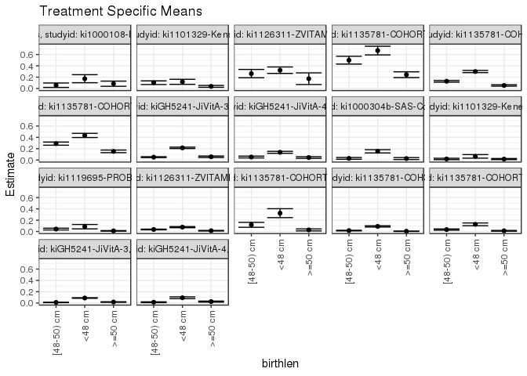

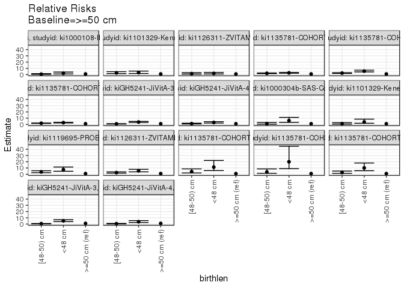

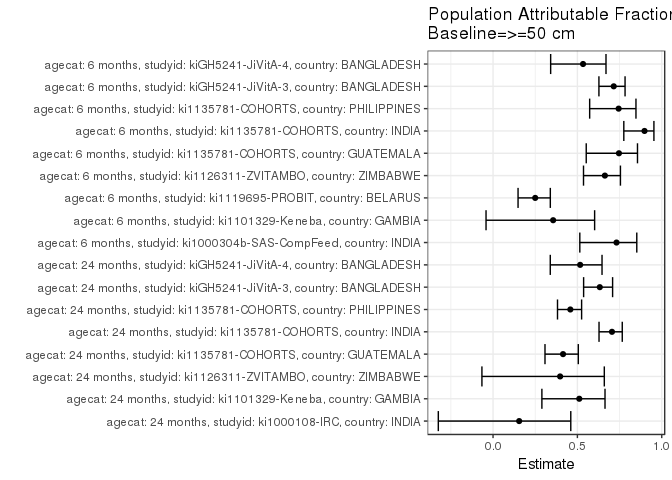

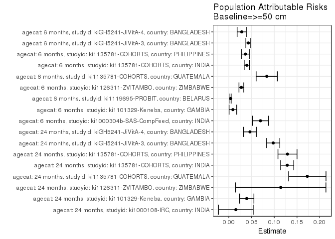

## Results Table

### Parameter: TSM

| agecat | studyid | country | intervention_level | baseline_level | estimate | ci_lower | ci_upper |
| --- | --- | --- | --- | --- | --- | --- | --- |
| 6 months | ki1000304b-SAS-CompFeed | INDIA | >=50 cm | NA | 0.0255102 | 0.0084713 | 0.0425492 |
| 6 months | ki1000304b-SAS-CompFeed | INDIA | <48 cm | NA | 0.1537377 | 0.1251875 | 0.1822879 |
| 6 months | ki1000304b-SAS-CompFeed | INDIA | [48-50) cm | NA | 0.0286396 | 0.0129545 | 0.0443247 |
| 6 months | ki1101329-Keneba | GAMBIA | >=50 cm | NA | 0.0162482 | 0.0067211 | 0.0257752 |
| 6 months | ki1101329-Keneba | GAMBIA | <48 cm | NA | 0.0641026 | 0.0327081 | 0.0954970 |
| 6 months | ki1101329-Keneba | GAMBIA | [48-50) cm | NA | 0.0183486 | 0.0057464 | 0.0309508 |
| 6 months | ki1119695-PROBIT | BELARUS | >=50 cm | NA | 0.0115642 | 0.0065819 | 0.0165466 |
| 6 months | ki1119695-PROBIT | BELARUS | <48 cm | NA | 0.0855341 | 0.0468636 | 0.1242046 |
| 6 months | ki1119695-PROBIT | BELARUS | [48-50) cm | NA | 0.0430863 | 0.0275484 | 0.0586241 |
| 6 months | ki1126311-ZVITAMBO | ZIMBABWE | >=50 cm | NA | 0.0140441 | 0.0093023 | 0.0187858 |
| 6 months | ki1126311-ZVITAMBO | ZIMBABWE | <48 cm | NA | 0.0771838 | 0.0671347 | 0.0872330 |
| 6 months | ki1126311-ZVITAMBO | ZIMBABWE | [48-50) cm | NA | 0.0360549 | 0.0296564 | 0.0424533 |
| 6 months | ki1135781-COHORTS | GUATEMALA | >=50 cm | NA | 0.0283892 | 0.0109795 | 0.0457989 |
| 6 months | ki1135781-COHORTS | GUATEMALA | <48 cm | NA | 0.3241676 | 0.2453400 | 0.4029951 |
| 6 months | ki1135781-COHORTS | GUATEMALA | [48-50) cm | NA | 0.1182457 | 0.0741499 | 0.1623414 |
| 6 months | ki1135781-COHORTS | INDIA | >=50 cm | NA | 0.0045113 | 0.0009094 | 0.0081131 |
| 6 months | ki1135781-COHORTS | INDIA | <48 cm | NA | 0.0901186 | 0.0789596 | 0.1012775 |
| 6 months | ki1135781-COHORTS | INDIA | [48-50) cm | NA | 0.0162637 | 0.0110657 | 0.0214618 |
| 6 months | ki1135781-COHORTS | PHILIPPINES | >=50 cm | NA | 0.0124879 | 0.0057118 | 0.0192639 |
| 6 months | ki1135781-COHORTS | PHILIPPINES | <48 cm | NA | 0.1263968 | 0.1019776 | 0.1508160 |
| 6 months | ki1135781-COHORTS | PHILIPPINES | [48-50) cm | NA | 0.0337916 | 0.0228921 | 0.0446912 |
| 6 months | kiGH5241-JiVitA-3 | BANGLADESH | >=50 cm | NA | 0.0170481 | 0.0123488 | 0.0217474 |
| 6 months | kiGH5241-JiVitA-3 | BANGLADESH | <48 cm | NA | 0.0887205 | 0.0830156 | 0.0944255 |
| 6 months | kiGH5241-JiVitA-3 | BANGLADESH | [48-50) cm | NA | 0.0108869 | 0.0070325 | 0.0147413 |
| 6 months | kiGH5241-JiVitA-4 | BANGLADESH | >=50 cm | NA | 0.0248321 | 0.0158531 | 0.0338112 |
| 6 months | kiGH5241-JiVitA-4 | BANGLADESH | <48 cm | NA | 0.0928087 | 0.0767665 | 0.1088508 |
| 6 months | kiGH5241-JiVitA-4 | BANGLADESH | [48-50) cm | NA | 0.0139100 | 0.0064706 | 0.0213493 |
| 24 months | ki1000108-IRC | INDIA | >=50 cm | NA | 0.0845070 | 0.0386997 | 0.1303144 |
| 24 months | ki1000108-IRC | INDIA | <48 cm | NA | 0.1727273 | 0.1019956 | 0.2434590 |
| 24 months | ki1000108-IRC | INDIA | [48-50) cm | NA | 0.0579710 | 0.0189316 | 0.0970105 |
| 24 months | ki1101329-Keneba | GAMBIA | >=50 cm | NA | 0.0376335 | 0.0211324 | 0.0541347 |
| 24 months | ki1101329-Keneba | GAMBIA | <48 cm | NA | 0.1178419 | 0.0734410 | 0.1622428 |
| 24 months | ki1101329-Keneba | GAMBIA | [48-50) cm | NA | 0.1022292 | 0.0702076 | 0.1342508 |
| 24 months | ki1126311-ZVITAMBO | ZIMBABWE | >=50 cm | NA | 0.1730769 | 0.0701373 | 0.2760166 |
| 24 months | ki1126311-ZVITAMBO | ZIMBABWE | <48 cm | NA | 0.3230769 | 0.2661696 | 0.3799843 |
| 24 months | ki1126311-ZVITAMBO | ZIMBABWE | [48-50) cm | NA | 0.2627737 | 0.1889895 | 0.3365579 |
| 24 months | ki1135781-COHORTS | GUATEMALA | >=50 cm | NA | 0.2436024 | 0.1923455 | 0.2948593 |
| 24 months | ki1135781-COHORTS | GUATEMALA | <48 cm | NA | 0.6700181 | 0.5930586 | 0.7469777 |
| 24 months | ki1135781-COHORTS | GUATEMALA | [48-50) cm | NA | 0.5003392 | 0.4312257 | 0.5694528 |
| 24 months | ki1135781-COHORTS | INDIA | >=50 cm | NA | 0.0537753 | 0.0408160 | 0.0667346 |
| 24 months | ki1135781-COHORTS | INDIA | <48 cm | NA | 0.2998661 | 0.2805237 | 0.3192085 |
| 24 months | ki1135781-COHORTS | INDIA | [48-50) cm | NA | 0.1280428 | 0.1131315 | 0.1429540 |
| 24 months | ki1135781-COHORTS | PHILIPPINES | >=50 cm | NA | 0.1526320 | 0.1295588 | 0.1757052 |
| 24 months | ki1135781-COHORTS | PHILIPPINES | <48 cm | NA | 0.4340086 | 0.3968856 | 0.4711315 |
| 24 months | ki1135781-COHORTS | PHILIPPINES | [48-50) cm | NA | 0.2892879 | 0.2612746 | 0.3173013 |
| 24 months | kiGH5241-JiVitA-3 | BANGLADESH | >=50 cm | NA | 0.0567170 | 0.0433196 | 0.0701144 |
| 24 months | kiGH5241-JiVitA-3 | BANGLADESH | <48 cm | NA | 0.2145274 | 0.2021868 | 0.2268679 |
| 24 months | kiGH5241-JiVitA-3 | BANGLADESH | [48-50) cm | NA | 0.0502492 | 0.0408335 | 0.0596649 |
| 24 months | kiGH5241-JiVitA-4 | BANGLADESH | >=50 cm | NA | 0.0435461 | 0.0286413 | 0.0584509 |
| 24 months | kiGH5241-JiVitA-4 | BANGLADESH | <48 cm | NA | 0.1360280 | 0.1188692 | 0.1531868 |
| 24 months | kiGH5241-JiVitA-4 | BANGLADESH | [48-50) cm | NA | 0.0522715 | 0.0364665 | 0.0680765 |

### Parameter: E(Y)

| agecat | studyid | country | intervention_level | baseline_level | estimate | ci_lower | ci_upper |
| --- | --- | --- | --- | --- | --- | --- | --- |
| 6 months | ki1000304b-SAS-CompFeed | INDIA | NA | NA | 0.0951662 | 0.0766361 | 0.1136962 |
| 6 months | ki1101329-Keneba | GAMBIA | NA | NA | 0.0252413 | 0.0168616 | 0.0336210 |
| 6 months | ki1119695-PROBIT | BELARUS | NA | NA | 0.0154178 | 0.0100323 | 0.0208033 |
| 6 months | ki1126311-ZVITAMBO | ZIMBABWE | NA | NA | 0.0416768 | 0.0373526 | 0.0460011 |
| 6 months | ki1135781-COHORTS | GUATEMALA | NA | NA | 0.1119186 | 0.0883438 | 0.1354934 |
| 6 months | ki1135781-COHORTS | INDIA | NA | NA | 0.0441728 | 0.0390306 | 0.0493149 |
| 6 months | ki1135781-COHORTS | PHILIPPINES | NA | NA | 0.0488708 | 0.0407385 | 0.0570030 |
| 6 months | kiGH5241-JiVitA-3 | BANGLADESH | NA | NA | 0.0599122 | 0.0560597 | 0.0637646 |
| 6 months | kiGH5241-JiVitA-4 | BANGLADESH | NA | NA | 0.0532338 | 0.0448583 | 0.0616093 |
| 24 months | ki1000108-IRC | INDIA | NA | NA | 0.1000000 | 0.0701878 | 0.1298122 |
| 24 months | ki1101329-Keneba | GAMBIA | NA | NA | 0.0769953 | 0.0609772 | 0.0930134 |
| 24 months | ki1126311-ZVITAMBO | ZIMBABWE | NA | NA | 0.2873051 | 0.2454033 | 0.3292069 |
| 24 months | ki1135781-COHORTS | GUATEMALA | NA | NA | 0.4163701 | 0.3755781 | 0.4571621 |
| 24 months | ki1135781-COHORTS | INDIA | NA | NA | 0.1823146 | 0.1713461 | 0.1932832 |
| 24 months | ki1135781-COHORTS | PHILIPPINES | NA | NA | 0.2817363 | 0.2638908 | 0.2995817 |
| 24 months | kiGH5241-JiVitA-3 | BANGLADESH | NA | NA | 0.1544292 | 0.1455642 | 0.1632942 |
| 24 months | kiGH5241-JiVitA-4 | BANGLADESH | NA | NA | 0.0900426 | 0.0798078 | 0.1002775 |

### Parameter: RR

| agecat | studyid | country | intervention_level | baseline_level | estimate | ci_lower | ci_upper |
| --- | --- | --- | --- | --- | --- | --- | --- |
| 6 months | ki1000304b-SAS-CompFeed | INDIA | >=50 cm | >=50 cm | 1.0000000 | 1.0000000 | 1.0000000 |
| 6 months | ki1000304b-SAS-CompFeed | INDIA | <48 cm | >=50 cm | 6.0265162 | 3.2342085 | 11.2296091 |
| 6 months | ki1000304b-SAS-CompFeed | INDIA | [48-50) cm | >=50 cm | 1.1226730 | 0.4128721 | 3.0527484 |
| 6 months | ki1101329-Keneba | GAMBIA | >=50 cm | >=50 cm | 1.0000000 | 1.0000000 | 1.0000000 |
| 6 months | ki1101329-Keneba | GAMBIA | <48 cm | >=50 cm | 3.9452214 | 1.8377214 | 8.4696038 |
| 6 months | ki1101329-Keneba | GAMBIA | [48-50) cm | >=50 cm | 1.1292744 | 0.4577236 | 2.7860931 |
| 6 months | ki1119695-PROBIT | BELARUS | >=50 cm | >=50 cm | 1.0000000 | 1.0000000 | 1.0000000 |
| 6 months | ki1119695-PROBIT | BELARUS | <48 cm | >=50 cm | 7.3964323 | 4.7458774 | 11.5273123 |
| 6 months | ki1119695-PROBIT | BELARUS | [48-50) cm | >=50 cm | 3.7258232 | 2.4851204 | 5.5859501 |
| 6 months | ki1126311-ZVITAMBO | ZIMBABWE | >=50 cm | >=50 cm | 1.0000000 | 1.0000000 | 1.0000000 |
| 6 months | ki1126311-ZVITAMBO | ZIMBABWE | <48 cm | >=50 cm | 5.4958219 | 3.8277417 | 7.8908298 |
| 6 months | ki1126311-ZVITAMBO | ZIMBABWE | [48-50) cm | >=50 cm | 2.5672637 | 1.7533840 | 3.7589273 |
| 6 months | ki1135781-COHORTS | GUATEMALA | >=50 cm | >=50 cm | 1.0000000 | 1.0000000 | 1.0000000 |
| 6 months | ki1135781-COHORTS | GUATEMALA | <48 cm | >=50 cm | 11.4186970 | 5.9057659 | 22.0778545 |
| 6 months | ki1135781-COHORTS | GUATEMALA | [48-50) cm | >=50 cm | 4.1651648 | 2.0331241 | 8.5329755 |
| 6 months | ki1135781-COHORTS | INDIA | >=50 cm | >=50 cm | 1.0000000 | 1.0000000 | 1.0000000 |
| 6 months | ki1135781-COHORTS | INDIA | <48 cm | >=50 cm | 19.9762846 | 8.9048026 | 44.8131154 |
| 6 months | ki1135781-COHORTS | INDIA | [48-50) cm | >=50 cm | 3.6051282 | 1.5255447 | 8.5195470 |
| 6 months | ki1135781-COHORTS | PHILIPPINES | >=50 cm | >=50 cm | 1.0000000 | 1.0000000 | 1.0000000 |
| 6 months | ki1135781-COHORTS | PHILIPPINES | <48 cm | >=50 cm | 10.1215686 | 5.6938216 | 17.9925117 |
| 6 months | ki1135781-COHORTS | PHILIPPINES | [48-50) cm | >=50 cm | 2.7059582 | 1.4403560 | 5.0836111 |
| 6 months | kiGH5241-JiVitA-3 | BANGLADESH | >=50 cm | >=50 cm | 1.0000000 | 1.0000000 | 1.0000000 |
| 6 months | kiGH5241-JiVitA-3 | BANGLADESH | <48 cm | >=50 cm | 5.2041250 | 3.9253841 | 6.8994313 |
| 6 months | kiGH5241-JiVitA-3 | BANGLADESH | [48-50) cm | >=50 cm | 0.6385993 | 0.4127793 | 0.9879591 |
| 6 months | kiGH5241-JiVitA-4 | BANGLADESH | >=50 cm | >=50 cm | 1.0000000 | 1.0000000 | 1.0000000 |
| 6 months | kiGH5241-JiVitA-4 | BANGLADESH | <48 cm | >=50 cm | 3.7374440 | 2.5095183 | 5.5662027 |
| 6 months | kiGH5241-JiVitA-4 | BANGLADESH | [48-50) cm | >=50 cm | 0.5601596 | 0.2919608 | 1.0747294 |
| 24 months | ki1000108-IRC | INDIA | >=50 cm | >=50 cm | 1.0000000 | 1.0000000 | 1.0000000 |
| 24 months | ki1000108-IRC | INDIA | <48 cm | >=50 cm | 2.0439394 | 1.0361710 | 4.0318521 |
| 24 months | ki1000108-IRC | INDIA | [48-50) cm | >=50 cm | 0.6859903 | 0.2889866 | 1.6283892 |
| 24 months | ki1101329-Keneba | GAMBIA | >=50 cm | >=50 cm | 1.0000000 | 1.0000000 | 1.0000000 |
| 24 months | ki1101329-Keneba | GAMBIA | <48 cm | >=50 cm | 3.1313022 | 1.7571517 | 5.5800836 |
| 24 months | ki1101329-Keneba | GAMBIA | [48-50) cm | >=50 cm | 2.7164394 | 1.5868957 | 4.6499859 |
| 24 months | ki1126311-ZVITAMBO | ZIMBABWE | >=50 cm | >=50 cm | 1.0000000 | 1.0000000 | 1.0000000 |
| 24 months | ki1126311-ZVITAMBO | ZIMBABWE | <48 cm | >=50 cm | 1.8666667 | 1.0038648 | 3.4710296 |
| 24 months | ki1126311-ZVITAMBO | ZIMBABWE | [48-50) cm | >=50 cm | 1.5182482 | 0.7865059 | 2.9307822 |
| 24 months | ki1135781-COHORTS | GUATEMALA | >=50 cm | >=50 cm | 1.0000000 | 1.0000000 | 1.0000000 |
| 24 months | ki1135781-COHORTS | GUATEMALA | <48 cm | >=50 cm | 2.7504581 | 2.1704997 | 3.4853817 |
| 24 months | ki1135781-COHORTS | GUATEMALA | [48-50) cm | >=50 cm | 2.0539178 | 1.6033591 | 2.6310877 |
| 24 months | ki1135781-COHORTS | INDIA | >=50 cm | >=50 cm | 1.0000000 | 1.0000000 | 1.0000000 |
| 24 months | ki1135781-COHORTS | INDIA | <48 cm | >=50 cm | 5.5762819 | 4.3482163 | 7.1511898 |
| 24 months | ki1135781-COHORTS | INDIA | [48-50) cm | >=50 cm | 2.3810718 | 1.8242682 | 3.1078231 |
| 24 months | ki1135781-COHORTS | PHILIPPINES | >=50 cm | >=50 cm | 1.0000000 | 1.0000000 | 1.0000000 |
| 24 months | ki1135781-COHORTS | PHILIPPINES | <48 cm | >=50 cm | 2.8434961 | 2.3924974 | 3.3795106 |
| 24 months | ki1135781-COHORTS | PHILIPPINES | [48-50) cm | >=50 cm | 1.8953293 | 1.5863500 | 2.2644896 |
| 24 months | kiGH5241-JiVitA-3 | BANGLADESH | >=50 cm | >=50 cm | 1.0000000 | 1.0000000 | 1.0000000 |
| 24 months | kiGH5241-JiVitA-3 | BANGLADESH | <48 cm | >=50 cm | 3.7824179 | 2.9659845 | 4.8235873 |
| 24 months | kiGH5241-JiVitA-3 | BANGLADESH | [48-50) cm | >=50 cm | 0.8859637 | 0.6539570 | 1.2002804 |
| 24 months | kiGH5241-JiVitA-4 | BANGLADESH | >=50 cm | >=50 cm | 1.0000000 | 1.0000000 | 1.0000000 |
| 24 months | kiGH5241-JiVitA-4 | BANGLADESH | <48 cm | >=50 cm | 3.1237674 | 2.1752828 | 4.4858178 |
| 24 months | kiGH5241-JiVitA-4 | BANGLADESH | [48-50) cm | >=50 cm | 1.2003703 | 0.7579954 | 1.9009202 |

### Parameter: PAR

| agecat | studyid | country | intervention_level | baseline_level | estimate | ci_lower | ci_upper |
| --- | --- | --- | --- | --- | --- | --- | --- |
| 6 months | ki1000304b-SAS-CompFeed | INDIA | >=50 cm | NA | 0.0696560 | 0.0518817 | 0.0874302 |
| 6 months | ki1101329-Keneba | GAMBIA | >=50 cm | NA | 0.0089931 | 0.0006416 | 0.0173447 |
| 6 months | ki1119695-PROBIT | BELARUS | >=50 cm | NA | 0.0038536 | 0.0024903 | 0.0052168 |
| 6 months | ki1126311-ZVITAMBO | ZIMBABWE | >=50 cm | NA | 0.0276327 | 0.0223563 | 0.0329091 |
| 6 months | ki1135781-COHORTS | GUATEMALA | >=50 cm | NA | 0.0835294 | 0.0601270 | 0.1069318 |
| 6 months | ki1135781-COHORTS | INDIA | >=50 cm | NA | 0.0396615 | 0.0338486 | 0.0454744 |
| 6 months | ki1135781-COHORTS | PHILIPPINES | >=50 cm | NA | 0.0363829 | 0.0276228 | 0.0451431 |
| 6 months | kiGH5241-JiVitA-3 | BANGLADESH | >=50 cm | NA | 0.0428640 | 0.0374806 | 0.0482475 |
| 6 months | kiGH5241-JiVitA-4 | BANGLADESH | >=50 cm | NA | 0.0284017 | 0.0182845 | 0.0385189 |
| 24 months | ki1000108-IRC | INDIA | >=50 cm | NA | 0.0154930 | -0.0227050 | 0.0536909 |
| 24 months | ki1101329-Keneba | GAMBIA | >=50 cm | NA | 0.0393618 | 0.0234968 | 0.0552268 |
| 24 months | ki1126311-ZVITAMBO | ZIMBABWE | >=50 cm | NA | 0.1142282 | 0.0147400 | 0.2137164 |
| 24 months | ki1135781-COHORTS | GUATEMALA | >=50 cm | NA | 0.1727677 | 0.1316814 | 0.2138541 |
| 24 months | ki1135781-COHORTS | INDIA | >=50 cm | NA | 0.1285394 | 0.1141047 | 0.1429740 |
| 24 months | ki1135781-COHORTS | PHILIPPINES | >=50 cm | NA | 0.1291043 | 0.1081483 | 0.1500603 |
| 24 months | kiGH5241-JiVitA-3 | BANGLADESH | >=50 cm | NA | 0.0977122 | 0.0831774 | 0.1122470 |
| 24 months | kiGH5241-JiVitA-4 | BANGLADESH | >=50 cm | NA | 0.0464965 | 0.0323964 | 0.0605966 |

### Parameter: PAF

| agecat | studyid | country | intervention_level | baseline_level | estimate | ci_lower | ci_upper |
| --- | --- | --- | --- | --- | --- | --- | --- |
| 6 months | ki1000304b-SAS-CompFeed | INDIA | >=50 cm | NA | 0.7319404 | 0.5143576 | 0.8520394 |
| 6 months | ki1101329-Keneba | GAMBIA | >=50 cm | NA | 0.3562864 | -0.0415418 | 0.6021598 |
| 6 months | ki1119695-PROBIT | BELARUS | >=50 cm | NA | 0.2499429 | 0.1482690 | 0.3394797 |
| 6 months | ki1126311-ZVITAMBO | ZIMBABWE | >=50 cm | NA | 0.6630240 | 0.5362568 | 0.7551386 |
| 6 months | ki1135781-COHORTS | GUATEMALA | >=50 cm | NA | 0.7463407 | 0.5524063 | 0.8562468 |
| 6 months | ki1135781-COHORTS | INDIA | >=50 cm | NA | 0.8978720 | 0.7751591 | 0.9536111 |
| 6 months | ki1135781-COHORTS | PHILIPPINES | >=50 cm | NA | 0.7444718 | 0.5727372 | 0.8471791 |
| 6 months | kiGH5241-JiVitA-3 | BANGLADESH | >=50 cm | NA | 0.7154481 | 0.6276342 | 0.7825532 |
| 6 months | kiGH5241-JiVitA-4 | BANGLADESH | >=50 cm | NA | 0.5335274 | 0.3414867 | 0.6695637 |
| 24 months | ki1000108-IRC | INDIA | >=50 cm | NA | 0.1549296 | -0.3244291 | 0.4607910 |
| 24 months | ki1101329-Keneba | GAMBIA | >=50 cm | NA | 0.5112232 | 0.2895397 | 0.6637353 |
| 24 months | ki1126311-ZVITAMBO | ZIMBABWE | >=50 cm | NA | 0.3975850 | -0.0659346 | 0.6595440 |
| 24 months | ki1135781-COHORTS | GUATEMALA | >=50 cm | NA | 0.4149379 | 0.3079447 | 0.5053897 |
| 24 months | ki1135781-COHORTS | INDIA | >=50 cm | NA | 0.7050414 | 0.6282444 | 0.7659737 |
| 24 months | ki1135781-COHORTS | PHILIPPINES | >=50 cm | NA | 0.4582450 | 0.3821118 | 0.5249975 |
| 24 months | kiGH5241-JiVitA-3 | BANGLADESH | >=50 cm | NA | 0.6327314 | 0.5369066 | 0.7087278 |
| 24 months | kiGH5241-JiVitA-4 | BANGLADESH | >=50 cm | NA | 0.5163833 | 0.3392404 | 0.6460360 |